# Optimal Treatment Analysis

## Outcome Variable

**Outcome Variable:** haz

## Predictor Variables

**Intervention Variable:** cleanck

**Adjustment Set:**

- arm
- sex
- W_mage
- meducyrs
- feducyrs
- hhwealth_quart
- W_nrooms
- W_nhh
- W_nchldlt5
- trth2o
- impfloor
- delta_meducyrs
- delta_feducyrs
- delta_hhwealth_quart
- delta_W_nrooms
- delta_W_nhh
- delta_W_nchldlt5
- delta_trth2o
- delta_impfloor

## Stratifying Variables

The analysis was stratified on these variable(s):

- agecat
- studyid
- country

## Data Summary

| agecat | studyid | country | cleanck | n_cell | n |
| --- | --- | --- | --- | --- | --- |
| Birth | ki0047075b-MAL-ED | PERU | 1 | 1 | 2 |
| Birth | ki0047075b-MAL-ED | PERU | 0 | 1 | 2 |
| Birth | ki1000108-CMC-V-BCS-2002 | INDIA | 1 | 39 | 92 |
| Birth | ki1000108-CMC-V-BCS-2002 | INDIA | 0 | 53 | 92 |
| Birth | ki1000108-IRC | INDIA | 1 | 218 | 378 |
| Birth | ki1000108-IRC | INDIA | 0 | 160 | 378 |
| Birth | ki1017093b-PROVIDE | BANGLADESH | 1 | 438 | 539 |
| Birth | ki1017093b-PROVIDE | BANGLADESH | 0 | 101 | 539 |
| Birth | ki1017093c-NIH-Crypto | BANGLADESH | 1 | 345 | 561 |
| Birth | ki1017093c-NIH-Crypto | BANGLADESH | 0 | 216 | 561 |
| Birth | ki1113344-GMS-Nepal | NEPAL | 1 | 9 | 621 |
| Birth | ki1113344-GMS-Nepal | NEPAL | 0 | 612 | 621 |
| 6 months | ki0047075b-MAL-ED | SOUTH AFRICA | 1 | 1 | 1 |
| 6 months | ki0047075b-MAL-ED | SOUTH AFRICA | 0 | 0 | 1 |
| 6 months | ki1000108-CMC-V-BCS-2002 | INDIA | 1 | 163 | 369 |
| 6 months | ki1000108-CMC-V-BCS-2002 | INDIA | 0 | 206 | 369 |
| 6 months | ki1000108-IRC | INDIA | 1 | 230 | 398 |
| 6 months | ki1000108-IRC | INDIA | 0 | 168 | 398 |
| 6 months | ki1017093b-PROVIDE | BANGLADESH | 1 | 498 | 604 |
| 6 months | ki1017093b-PROVIDE | BANGLADESH | 0 | 106 | 604 |
| 6 months | ki1017093c-NIH-Crypto | BANGLADESH | 1 | 329 | 545 |
| 6 months | ki1017093c-NIH-Crypto | BANGLADESH | 0 | 216 | 545 |
| 6 months | ki1113344-GMS-Nepal | NEPAL | 1 | 8 | 505 |
| 6 months | ki1113344-GMS-Nepal | NEPAL | 0 | 497 | 505 |
| 24 months | ki0047075b-MAL-ED | SOUTH AFRICA | 1 | 1 | 1 |
| 24 months | ki0047075b-MAL-ED | SOUTH AFRICA | 0 | 0 | 1 |
| 24 months | ki1000108-CMC-V-BCS-2002 | INDIA | 1 | 163 | 371 |
| 24 months | ki1000108-CMC-V-BCS-2002 | INDIA | 0 | 208 | 371 |
| 24 months | ki1000108-IRC | INDIA | 1 | 231 | 400 |
| 24 months | ki1000108-IRC | INDIA | 0 | 169 | 400 |
| 24 months | ki1017093b-PROVIDE | BANGLADESH | 1 | 479 | 578 |
| 24 months | ki1017093b-PROVIDE | BANGLADESH | 0 | 99 | 578 |
| 24 months | ki1017093c-NIH-Crypto | BANGLADESH | 1 | 199 | 410 |
| 24 months | ki1017093c-NIH-Crypto | BANGLADESH | 0 | 211 | 410 |
| 24 months | ki1113344-GMS-Nepal | NEPAL | 1 | 5 | 435 |
| 24 months | ki1113344-GMS-Nepal | NEPAL | 0 | 430 | 435 |

The following strata were considered:

- agecat: 24 months, studyid: ki0047075b-MAL-ED, country: SOUTH AFRICA
- agecat: 24 months, studyid: ki1000108-CMC-V-BCS-2002, country: INDIA
- agecat: 24 months, studyid: ki1000108-IRC, country: INDIA
- agecat: 24 months, studyid: ki1017093b-PROVIDE, country: BANGLADESH
- agecat: 24 months, studyid: ki1017093c-NIH-Crypto, country: BANGLADESH
- agecat: 24 months, studyid: ki1113344-GMS-Nepal, country: NEPAL
- agecat: 6 months, studyid: ki0047075b-MAL-ED, country: SOUTH AFRICA
- agecat: 6 months, studyid: ki1000108-CMC-V-BCS-2002, country: INDIA
- agecat: 6 months, studyid: ki1000108-IRC, country: INDIA
- agecat: 6 months, studyid: ki1017093b-PROVIDE, country: BANGLADESH
- agecat: 6 months, studyid: ki1017093c-NIH-Crypto, country: BANGLADESH
- agecat: 6 months, studyid: ki1113344-GMS-Nepal, country: NEPAL
- agecat: Birth, studyid: ki0047075b-MAL-ED, country: PERU
- agecat: Birth, studyid: ki1000108-CMC-V-BCS-2002, country: INDIA
- agecat: Birth, studyid: ki1000108-IRC, country: INDIA
- agecat: Birth, studyid: ki1017093b-PROVIDE, country: BANGLADESH
- agecat: Birth, studyid: ki1017093c-NIH-Crypto, country: BANGLADESH
- agecat: Birth, studyid: ki1113344-GMS-Nepal, country: NEPAL

### Dropped Strata

Some strata were dropped due to rare outcomes:

- agecat: Birth, studyid: ki0047075b-MAL-ED, country: PERU
- agecat: 6 months, studyid: ki0047075b-MAL-ED, country: SOUTH AFRICA
- agecat: 24 months, studyid: ki0047075b-MAL-ED, country: SOUTH AFRICA

## Methods Detail

We’re interested in the causal parameters $E[Y_a]$ for all values of $a \in \mathcal{A}$. These parameters represent the mean outcome if, possibly contrary to fact, we intervened to set all units to have $A=a$. Under the randomization and positivity assumptions, these are identified by the statistical parameters $\psi_a=E_W[E_{Y|A,W}(Y|A=a,W)]$. In addition, we’re interested in the mean of $Y$, $E[Y]$ under no intervention (the observed mean). We will estimate these parameters by using SuperLearner to fit the relevant likelihood factors – $E_{Y|A,W}(Y|A=a,W)$ and $p(A=a|W)$, and then updating our likelihood fit using a joint TMLE.

For unadjusted analyses ($W=\{\}$), initial likelihoods were estimated using Lrnr_glm to estimate the simple $E(Y|A)$ and Lrnr_mean to estimate $p(A)$. For adjusted analyses, a small library containing Lrnr_glmnet, Lrnr_xgboost, and Lrnr_mean was used.

Having estimated these parameters, we will then use the delta method to estimate relative risks and attributable risks relative to a prespecified baseline level of $A$.

# Results Detail

## Results Plots

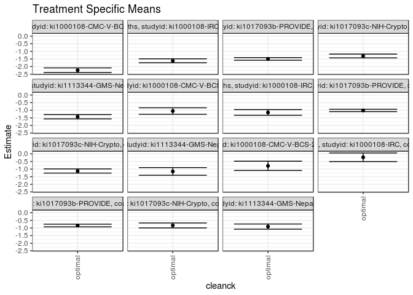

## Results Table

### Parameter: TSM

| agecat | studyid | country | intervention_level | baseline_level | estimate | ci_lower | ci_upper |
| --- | --- | --- | --- | --- | --- | --- | --- |
| Birth | ki1000108-CMC-V-BCS-2002 | INDIA | optimal | observed | -0.7863437 | -1.0907674 | -0.4819200 |
| Birth | ki1000108-IRC | INDIA | optimal | observed | -0.2230343 | -0.5063176 | 0.0602491 |
| Birth | ki1017093b-PROVIDE | BANGLADESH | optimal | observed | -0.8368658 | -0.9261811 | -0.7475506 |
| Birth | ki1017093c-NIH-Crypto | BANGLADESH | optimal | observed | -0.8328377 | -0.9965295 | -0.6691459 |
| Birth | ki1113344-GMS-Nepal | NEPAL | optimal | observed | -0.9090675 | -1.0785303 | -0.7396047 |
| 6 months | ki1000108-CMC-V-BCS-2002 | INDIA | optimal | observed | -1.0534607 | -1.2660317 | -0.8408896 |
| 6 months | ki1000108-IRC | INDIA | optimal | observed | -1.1460476 | -1.3320600 | -0.9600353 |
| 6 months | ki1017093b-PROVIDE | BANGLADESH | optimal | observed | -1.0124395 | -1.0925006 | -0.9323784 |
| 6 months | ki1017093c-NIH-Crypto | BANGLADESH | optimal | observed | -1.1244549 | -1.2623423 | -0.9865676 |
| 6 months | ki1113344-GMS-Nepal | NEPAL | optimal | observed | -1.1526206 | -1.4043477 | -0.9008936 |
| 24 months | ki1000108-CMC-V-BCS-2002 | INDIA | optimal | observed | -2.2410266 | -2.3937322 | -2.0883210 |
| 24 months | ki1000108-IRC | INDIA | optimal | observed | -1.6199765 | -1.7497222 | -1.4902308 |
| 24 months | ki1017093b-PROVIDE | BANGLADESH | optimal | observed | -1.4963578 | -1.5836759 | -1.4090397 |
| 24 months | ki1017093c-NIH-Crypto | BANGLADESH | optimal | observed | -1.3033445 | -1.4275302 | -1.1791588 |
| 24 months | ki1113344-GMS-Nepal | NEPAL | optimal | observed | -1.4286807 | -1.5702526 | -1.2871088 |

### Parameter: E(Y)

| agecat | studyid | country | intervention_level | baseline_level | estimate | ci_lower | ci_upper |
| --- | --- | --- | --- | --- | --- | --- | --- |
| Birth | ki1000108-CMC-V-BCS-2002 | INDIA | observed | observed | -0.9611957 | -1.1776967 | -0.7446946 |
| Birth | ki1000108-IRC | INDIA | observed | observed | -0.3176455 | -0.4788394 | -0.1564516 |
| Birth | ki1017093b-PROVIDE | BANGLADESH | observed | observed | -0.8851020 | -0.9601332 | -0.8100709 |
| Birth | ki1017093c-NIH-Crypto | BANGLADESH | observed | observed | -0.8996078 | -0.9825064 | -0.8167093 |
| Birth | ki1113344-GMS-Nepal | NEPAL | observed | observed | -1.0998712 | -1.1839267 | -1.0158156 |
| 6 months | ki1000108-CMC-V-BCS-2002 | INDIA | observed | observed | -1.4234508 | -1.5645974 | -1.2823042 |
| 6 months | ki1000108-IRC | INDIA | observed | observed | -1.2373869 | -1.3694835 | -1.1052903 |
| 6 months | ki1017093b-PROVIDE | BANGLADESH | observed | observed | -1.0916915 | -1.1661176 | -1.0172654 |
| 6 months | ki1017093c-NIH-Crypto | BANGLADESH | observed | observed | -1.1482385 | -1.2287866 | -1.0676904 |
| 6 months | ki1113344-GMS-Nepal | NEPAL | observed | observed | -1.3650165 | -1.4477401 | -1.2822929 |
| 24 months | ki1000108-CMC-V-BCS-2002 | INDIA | observed | observed | -2.5588679 | -2.6583730 | -2.4593629 |
| 24 months | ki1000108-IRC | INDIA | observed | observed | -1.8039875 | -1.8980579 | -1.7099171 |
| 24 months | ki1017093b-PROVIDE | BANGLADESH | observed | observed | -1.6024221 | -1.6857420 | -1.5191023 |
| 24 months | ki1017093c-NIH-Crypto | BANGLADESH | observed | observed | -1.3408537 | -1.4302211 | -1.2514862 |
| 24 months | ki1113344-GMS-Nepal | NEPAL | observed | observed | -1.8970805 | -1.9859605 | -1.8082004 |

### Parameter: PAR

| agecat | studyid | country | intervention_level | baseline_level | estimate | ci_lower | ci_upper |
| --- | --- | --- | --- | --- | --- | --- | --- |
| Birth | ki1000108-CMC-V-BCS-2002 | INDIA | optimal | observed | -0.1748519 | -0.4471785 | 0.0974746 |
| Birth | ki1000108-IRC | INDIA | optimal | observed | -0.0946112 | -0.3042419 | 0.1150194 |
| Birth | ki1017093b-PROVIDE | BANGLADESH | optimal | observed | -0.0482362 | -0.1034744 | 0.0070020 |
| Birth | ki1017093c-NIH-Crypto | BANGLADESH | optimal | observed | -0.0667701 | -0.1987087 | 0.0651685 |
| Birth | ki1113344-GMS-Nepal | NEPAL | optimal | observed | -0.1908037 | -0.3763614 | -0.0052460 |
| 6 months | ki1000108-CMC-V-BCS-2002 | INDIA | optimal | observed | -0.3699901 | -0.5310696 | -0.2089106 |
| 6 months | ki1000108-IRC | INDIA | optimal | observed | -0.0913393 | -0.2016787 | 0.0190001 |
| 6 months | ki1017093b-PROVIDE | BANGLADESH | optimal | observed | -0.0792520 | -0.1197014 | -0.0388026 |
| 6 months | ki1017093c-NIH-Crypto | BANGLADESH | optimal | observed | -0.0237836 | -0.1354751 | 0.0879079 |
| 6 months | ki1113344-GMS-Nepal | NEPAL | optimal | observed | -0.2123959 | -0.4717017 | 0.0469100 |
| 24 months | ki1000108-CMC-V-BCS-2002 | INDIA | optimal | observed | -0.3178414 | -0.4418521 | -0.1938307 |
| 24 months | ki1000108-IRC | INDIA | optimal | observed | -0.1840110 | -0.2712210 | -0.0968010 |
| 24 months | ki1017093b-PROVIDE | BANGLADESH | optimal | observed | -0.1060644 | -0.1491479 | -0.0629808 |
| 24 months | ki1017093c-NIH-Crypto | BANGLADESH | optimal | observed | -0.0375091 | -0.1302628 | 0.0552445 |
| 24 months | ki1113344-GMS-Nepal | NEPAL | optimal | observed | -0.4683997 | -0.6327365 | -0.3040629 |